# MAGIC_UMAP_99

## Summary

This notebook processes scRNASeq time course data. Some of the code was adapted from Cook et al., 2020.

```r
rm(list=ls())
```

## 1. Load Libraries

```r
library(tidyverse)
library(readxl)
library(umap)
library(Seurat)
library(writexl)
library(ggpubr)
library(gridExtra)
library(extrafont)
library(tools)
#loadfonts(device="win")
```

## 2. Load scRNASeq datasets

Next, we’ll load the A549 dataset, which is the lung cancer cell line investigated in GSE147405. Additionally, we’ll focus on the $TGF \beta 1$ sample, since this was the way EMT was induced in many bulk experiments.

```r
filepath = 'D:/Chandrasekaran/Projects/EMT/Data/scRNASeq/a549_quantile.rds'
a549 = readRDS(filepath)
```

### A. Visualize Time-Course

This bit of code separates groups by time point and creates individual UMAP plots. This may be useful for later.

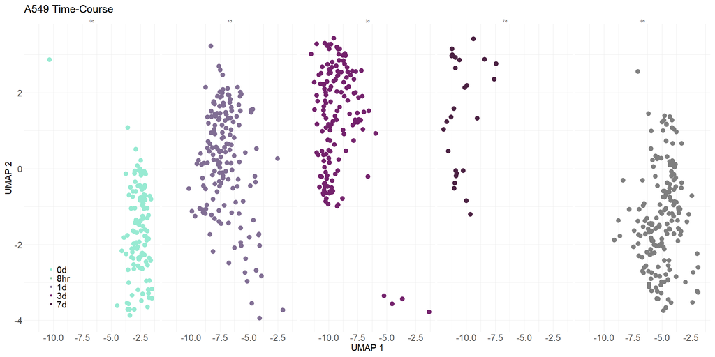

```r
colmap = c('0d' = '#97EAD2',
           '8hr'= '#8CC7A1',
           '1d' = '#816E94',
           '3d' = '#74226C',
           '7d' = '#4B2142')
pA = DimPlot(a549,
        reduction="umap",
        dims=c(1, 2),
        split.by='Time',
        group.by='Time',
        cols=colmap,
        label=FALSE,
        repel=TRUE,
        label.size=4,
        pt.size=5,
        na.value = "grey50") +
        labs(title="A549 Time-Course",
             x="UMAP 1",
             y="UMAP 2") +
        theme_minimal() +
        theme(plot.title = element_text(size=26),
              legend.text=element_text(size=22),
              axis.title.x=element_text(size=22),
              axis.title.y=element_text(size=22),
              axis.text.x=element_text(size=22),
              axis.text.y=element_text(size=22),
              legend.position=c(0.05, 0.15),
              legend.box="vertical",
              legend.margin=margin(),
              text=element_text(family="sans")) +
        guides(color=guide_legend(override.aes=list(size=2)))

pA
```

This embedding just changes subpopulations to time, which is what I originally wanted.

```r
pB = DimPlot(a549,
        reduction="umap",
        dims=c(1, 2),
        group.by='Time',
        cols = colmap,
        label=FALSE,
        repel=TRUE,
        label.size=4,
        pt.size=5,
        na.value = "grey50") +
        labs(title="A549 Time-Course",
             x="UMAP 1",
             y="UMAP 2",
             tag="A.",
) +
        theme_minimal() +
        theme(plot.title = element_text(size=22),
              plot.tag=element_text(size=26, face="bold"),
              legend.text=element_text(size=10),
              axis.title.x=element_text(size=22),
              axis.title.y=element_text(size=22),
              axis.text.x=element_text(size=22),
              axis.text.y=element_text(size=22),
              legend.position=c(0.15, 0.15),
              legend.box="vertical",
              legend.margin=margin(),
              text=element_text(family="sans"))
```

[output not shown]

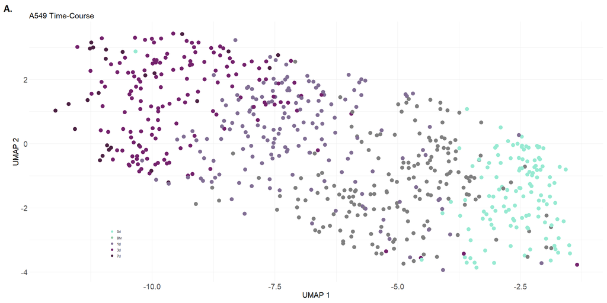

```r
pB
```

## 3. Overlay growth rates from KO onto the UMAP embedding

### A. Load up and map the knockout data

We’ll read in the metabolic KO data computed from single-cell Flux Balance Analysis

```r
ko_path = 'D:/Chandrasekaran/Projects/EMT/Analysis/i99/rxnko_i99.csv'
ko_data = readr::read_csv(ko_path)
```

```r
a549_id_map = read_csv("D:/Chandrasekaran/Projects/EMT/Analysis/data/a549_colmap.csv")
```

```r
col_names = colnames(ko_data[, 4:ncol(ko_data)])
col_names = stringr::str_replace(col_names, '_[^_]+$', '')
col_names = stringr::str_replace(col_names, 'x', '')

rxnmap = ko_data[1:3]
ko_data[1:3] = NULL

ko_data = t(ko_data)
ko_data = as.data.frame(ko_data)

rownames(ko_data) = a549_id_map$orig_id
colnames(ko_data) = rxnmap$rxn_ids
```

Now let’s load up the control.

```r
xl_path = "D:/Chandrasekaran/Projects/EMT/Data/COBRA/Unconstrained i99 KO Grate.xlsx"
cntr_grate = read_excel(xl_path, sheet="cntr_rxn_grate")
```

### B. Data Transformations

#### i. Control fold change Normalization

```r
tmp = cntr_grate[, 2]
mnorm_ko = ((ko_data+1) / (t(tmp)+1))-1
```

Let’s visualize the fold change distribution.

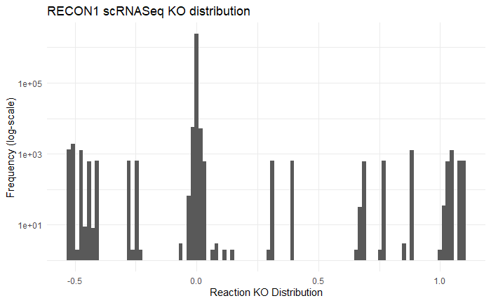

```r
library(reshape2)
tmp = melt(mnorm_ko)
ggplot(tmp, aes(x=value)) +
  geom_histogram(bins=100) +
  scale_y_continuous(trans='log10') +
  ggtitle("RECON1 scRNASeq KO distribution") +
  xlab("Reaction KO Distribution") +
  ylab("Frequency (log-scale)") +
  theme_minimal()
```

#### ii. Z-score Transformation

Alternatively, let’s see the impact of a Z-score transformation.

```r
tmp = cntr_grate[, 2]
zko = (ko_data - t(tmp)) / apply(ko_data, 2, sd, na.rm=TRUE)
```

Let’s visualize the Z-score distirbution.

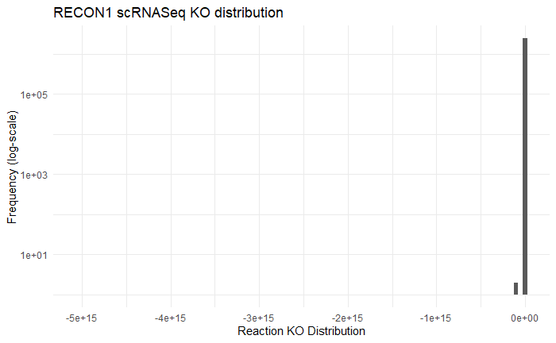

```r
library(reshape2)
tmp = melt(zko)
ggplot(tmp, aes(x=value)) +
  geom_histogram(bins=100) +
  scale_y_continuous(trans='log10') +
  ggtitle("RECON1 scRNASeq KO distribution") +
  xlab("Reaction KO Distribution") +
  ylab("Frequency (log-scale)") +
  theme_minimal()
```

## Create density map profiles for glycolysis

In Mohit’s paper, they are able to show through density plots that there are deferentially active metabolic pathways. What this density plot will show are metabolic reactions for A549 glycolysis over time.

First, change the row to map to time.

[figure not shown]

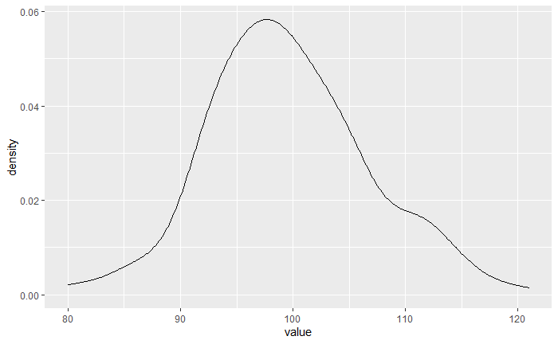

```r
set.seed(1234)
df = data.frame(value =round(c(rnorm(200,
                                      mean=100,
                                      sd=7))))

# import libraries ggplot2
library(ggplot2)

# create density plot
ggplot(df, aes(x=value)) + geom_density()
```

[figure not shown]

### C. Merge with UMAP embedding

This combines the reaction ko data with the UMAP embedding.

```r
umap_data = data.frame(a549@reductions$umap@cell.embeddings)
```

#### i. Mean Normalization

```r
merged_meanko = merge(umap_data, mnorm_ko, by.x='row.names', by.y='row.names')
rownames(merged_meanko) = merged_meanko$Row.names
merged_meanko = merged_meanko[, -1]
```

#### ii. Z-score

```r
merged_zko = merge(umap_data, zko, by.x='row.names', by.y='row.names')
rownames(merged_zko) = merged_zko$Row.names
merged_zko = merged_zko[, -1]
```

### D. Visualize KO Data

Let’s intialize some variables we need to declare for the visualization.

This code block does it by sorting the reactions based on standard deviation.

```r
col_sd = apply(mnorm_ko, 2, sd, na.rm=TRUE)
sorted_sd = sort(col_sd, index.return=TRUE, decreasing=TRUE)
tmp_rxns = mnorm_ko[, sorted_sd$ix]
```

Now merge with the UMAP coordinates.

```r
merged_meanko = merge(umap_data, tmp_rxns, by.x='row.names', by.y='row.names')
rownames(merged_meanko) = merged_meanko$Row.names
merged_meanko = merged_meanko[, -1]
```

Let’s look at the top 100 most varied reactions

```r
#tmp2 = merged_meanko[, 900:1000]
tmp2 = merged_meanko[, 1:100]
tmp3 = data.frame(colnames(tmp2))
reaction_names = rxnmap[rxnmap$rxn_ids %in% tmp3[3:nrow(tmp3), ], ]
reaction_names = reaction_names$rxn_name
```

```r
reactions_to_visualize = c("FACOAL204i", "CSm", "ACCOACm", "ENMAN6g", "NNATn")
reaction_names = rxnmap[rxnmap$rxn_ids %in% reactions_to_visualize, ]
reaction_names = reaction_names$rxn_name
#reaction_names[4] = "Enolase"
#reaction_names[3] = "Nicotinamide-nucleotide adenylyltransferase"
```

```r
reactions_to_visualize = c("AKGMALtm", "CSNATm", "ACITL", "ENMAN6g", "CSm")
reaction_names = rxnmap[rxnmap$rxn_ids %in% reactions_to_visualize, ]
reaction_names = reaction_names$rxn_name
#reaction_names[4] = "Enolase"
#reaction_names[3] = "Nicotinamide-nucleotide adenylyltransferase"
```

Finally, grab glycolysis reactions

```r
#tmp = FindAllMarkers(a549, assay="FBA")
reactions_to_visualize = c(
  'ENMAN6g',
  'FBA',
  'GAPD',
  'HEX1',
  'LDH_L',
  'PDHm',
  'PEPCK',
  'PEPCKm',
  'PFK',
  'PGI',
  'PGK',
  'PGM',
  'PGMT',
  'PYK',
  'TPI'
)
reaction_names = rxnmap[rxnmap$rxn_ids %in% reactions_to_visualize, ]
reaction_names = reaction_names$rxn_name
```

```r
reaction_names
```

#### i. Set 1: Flux

#### ii. Set 2: KO

```r
reactions_to_visualize = c("APAT2rm", "BALAtmr", "MMSAD3m",
                           "PCm", "GAPD", "EX_h_e")
reaction_names = c("3-Aminopropanoate:2-oxoglutarate aminotransferase (m)",
                   "Beta-alanine reversible mitochondrial transport (diffusion)",
                   "methylmalonate-semialdehyde dehydrogenase (malonic semialdehyde), mitochondrial",
                   "pyruvate carboxylase",
                   "glyceraldehyde-3-phosphate dehydrogenase",
                   "H+ exchange")
```

#### iii. Set 3: KO

#### iv. Set 4: KO

#### v. Visualize mean-norm KO

```r
tmp3 = rxnmap[rxnmap$rxn_ids %in% colnames(tmp2)]
```

```
Error: Must subset columns with a valid subscript vector.
i Logical subscripts must match the size of the indexed input.
x Input has size 3 but subscript `rxnmap$rxn_ids %in% colnames(tmp2)` has size 3744.
Run `rlang::last_error()` to see where the error occurred.
```

```r
p = list()
p[[1]] = ggplot(merged_meanko, aes(x=UMAP_1, y=UMAP_2, color=tmp2[, 1])) +
                geom_point(size=5) +
                theme_minimal() +
                labs(x="UMAP 1",
                     y="UMAP 2",
                     tag="B.",
                     title=toTitleCase(as.character(rxnmap[rxnmap$rxn_ids %in% colnames(tmp2)[1], 'rxn_name'])),
                     color="Growth classification") +
                scale_colour_manual(values = c("Sensitive"="red",
                             "Not Sensitive"="gray",
                             "Mildly enhancing"="#6D6A6A",
                             "Enhancing"="black")) +
                #scale_colour_gradient2(low="red", mid='#F07470', high='black', na.value='gray', limits=c(min(tmp), 1), midpoint=0) +
                theme(plot.title = element_text(size=22),
                      plot.tag=element_text(size=26, face="bold"),
                      legend.text=element_text(size=10),
                      axis.title.x=element_text(size=22),
                      axis.title.y=element_text(size=22),
                      axis.text.x=element_text(size=22),
                      axis.text.y=element_text(size=22),
                      legend.position=c(0.15, 0.15),
                      legend.box="vertical",
                      legend.margin=margin(),
                      text=element_text(family="sans"))


p[[2]] = ggplot(merged_meanko, aes(x=UMAP_1, y=UMAP_2, color=tmp2[, 3])) +
                geom_point(size=5) +
                theme_minimal() +
                labs(x="UMAP 1",
                     y="UMAP 2",
                     tag="C.",
                     title=toTitleCase(as.character(rxnmap[rxnmap$rxn_ids %in% colnames(tmp2)[3], 'rxn_name'])),
                     color="Growth classification") +
                scale_colour_manual(values = c("Sensitive"="red",
                             "Not Sensitive"="gray",
                             "Mildly enhancing"="#6D6A6A",
                             "Enhancing"="black")) +
                #scale_colour_gradient2(low="red", mid='#F07470', high='bl
                #scale_colour_gradient2(low="red", mid='#F07470', high='black', na.value='gray', limits=c(min(tmp), 1), midpoint=0) +
                theme(plot.title = element_text(size=22),
                      plot.tag=element_text(size=26, face="bold"),
                      legend.text=element_text(size=10),
                      axis.title.x=element_text(size=22),
                      axis.title.y=element_text(size=22),
                      axis.text.x=element_text(size=22),
                      axis.text.y=element_text(size=22),
                      legend.position=c(0.15, 0.15),
                      legend.box="vertical",
                      legend.margin=margin(),
                      text=element_text(family="sans"))

p[[3]] = ggplot(merged_meanko, aes(x=UMAP_1, y=UMAP_2, color=tmp2[, 4])) +
                geom_point(size=5) +
                theme_minimal() +
                labs(x="UMAP 1",
                     y="UMAP 2",
                     tag="D.",
                     title=toTitleCase(as.character(rxnmap[rxnmap$rxn_ids %in% colnames(tmp2)[4], 'rxn_name'])),
                     color="Growth classification") +
                scale_colour_manual(values = c("Sensitive"="red",
                             "Not Sensitive"="gray",
                             "Mildly enhancing"="#6D6A6A",
                             "Enhancing"="black")) +
                #scale_colour_gradient2(low="red", mid='#F07470', high='black', na.value='gray', limits=c(min(tmp), 1), midpoint=0) +
                theme(plot.title = element_text(size=22),
                      plot.tag=element_text(size=26, face="bold"),
                      legend.text=element_text(size=10),
                      axis.title.x=element_text(size=22),
                      axis.title.y=element_text(size=22),
                      axis.text.x=element_text(size=22),
                      axis.text.y=element_text(size=22),
                      legend.position=c(0.15, 0.15),
                      legend.box="vertical",
                      legend.margin=margin(),
                      text=element_text(family="sans"))

p[[4]] = ggplot(merged_meanko, aes(x=UMAP_1, y=UMAP_2, color=tmp2[, 7])) +
                geom_point(size=5) +
                theme_minimal() +
                labs(x="UMAP 1",
                     y="UMAP 2",
                     tag="E.",
                     title=toTitleCase(as.character(rxnmap[rxnmap$rxn_ids %in% colnames(tmp2)[7], 'rxn_name'])),
                     color="Growth classification") +
                scale_colour_manual(values = c("Sensitive"="red",
                             "Not Sensitive"="gray",
                             "Mildly enhancing"="#6D6A6A",
                             "Enhancing"="black")) +
                #scale_colour_gradient2(low="red", mid='#F07470', high='black', na.value='gray', limits=c(min(tmp), 1), midpoint=0) +
                theme(plot.title = element_text(size=22),
                      plot.tag=element_text(size=26, face="bold"),
                      legend.text=element_text(size=10),
                      axis.title.x=element_text(size=22),
                      axis.title.y=element_text(size=22),
                      axis.text.x=element_text(size=22),
                      axis.text.y=element_text(size=22),
                      legend.position=c(0.15, 0.15),
                      legend.box="vertical",
                      legend.margin=margin(),
                      text=element_text(family="sans"))

p[[5]] = ggplot(merged_meanko, aes(x=UMAP_1, y=UMAP_2, color=tmp2[, 12])) +
                geom_point(size=5) +
                theme_minimal() +
                labs(x="UMAP 1",
                     y="UMAP 2",
                     tag="F.",
                     title=toTitleCase(as.character(rxnmap[rxnmap$rxn_ids %in% colnames(tmp2)[12], 'rxn_name'])),
                     color="Growth classification") +
                scale_colour_manual(values = c("Sensitive"="red",
                             "Not Sensitive"="gray",
                             "Mildly enhancing"="#6D6A6A",
                             "Enhancing"="black")) +
                #scale_colour_gradient2(low="red", mid='#F07470', high='black', na.value='gray', limits=c(min(tmp), 1), midpoint=0) +
                theme(plot.title = element_text(size=22),
                      plot.tag=element_text(size=26, face="bold"),
                      legend.text=element_text(size=10),
                      axis.title.x=element_text(size=22),
                      axis.title.y=element_text(size=22),
                      axis.text.x=element_text(size=22),
                      axis.text.y=element_text(size=22),
                      legend.position=c(0.15, 0.15),
                      legend.box="vertical",
                      legend.margin=margin(),
                      text=element_text(family="sans"))
```

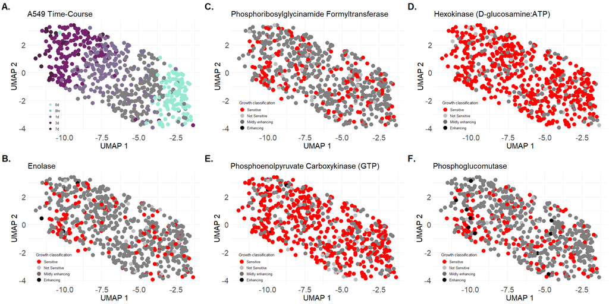

```r
pC = scater::multiplot(pB,     p[[1]], p[[2]],
                       p[[4]], p[[3]], p[[5]], cols=3)
```

```r
pC
```

| z | cells | name | grob |
| --- | --- | --- | --- |
| 1 | (1-1,1-1) | arrange | gtable[layout] |
| 2 | (2-2,1-1) | arrange | gtable[layout] |
| 3 | (1-1,2-2) | arrange | gtable[layout] |
| 4 | (2-2,2-2) | arrange | gtable[layout] |
| 5 | (1-1,3-3) | arrange | gtable[layout] |
| 6 | (2-2,3-3) | arrange | gtable[layout] |

Now, let’s visualize the distributions of knockouts

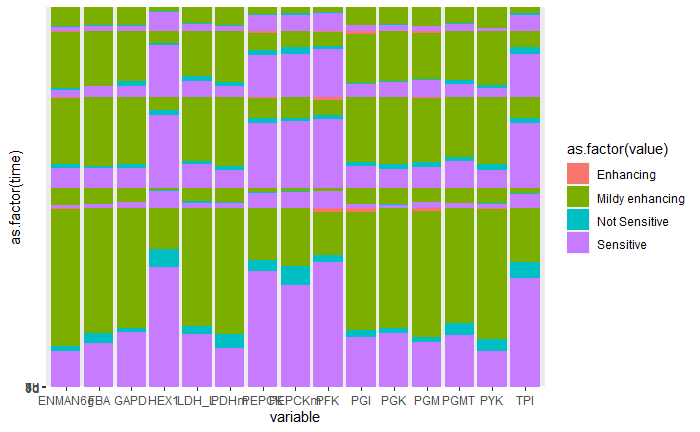

#### v. Visualize Z-score KO

```r
tmp = merged_zko[, reactions_to_visualize]
tmp[is.na(tmp)] = 0
```

```r
p = list()

p[[1]] = ggplot(merged_zko, aes(x=UMAP_1, y=UMAP_2, color=tmp[, reactions_to_visualize[1]])) +
                geom_point(size=5) +
                theme_minimal() +
                labs(x="UMAP 1",
                     y="UMAP 2",
                     title=reaction_names[1],
                     color="Flux") +
                scale_colour_gradient2(low="red", mid = 'gray', high='black') +
                theme(plot.title = element_text(size=26),
                            legend.text=element_text(size=10),
                            axis.title.x=element_text(size=22),
                            axis.title.y=element_text(size=22),
                            axis.text.x=element_text(size=22),
                            axis.text.y=element_text(size=22),
                            legend.position=c(0.05, 0.15),
                            legend.box="vertical",
                            legend.margin=margin(),
                            text=element_text(family="sans"))


p[[2]] = ggplot(merged_zko, aes(x=UMAP_1, y=UMAP_2, color=tmp[, reactions_to_visualize[2]])) +
                geom_point(size=5) +
                theme_minimal() +
                labs(x="UMAP 1",
                     y="UMAP 2",
                     title=reaction_names[2],
                     color="Flux") +
                scale_colour_gradient2(low="red", mid = 'gray', high='black') +
                theme(plot.title = element_text(size=26),
                            legend.text=element_text(size=22),
                            axis.title.x=element_text(size=22),
                            axis.title.y=element_text(size=22),
                            axis.text.x=element_text(size=22),
                            axis.text.y=element_text(size=22),
                            legend.position=c(0.05, 0.15),
                            legend.box="vertical",
                            legend.margin=margin(),
                            text=element_text(family="sans"))

p[[3]] = ggplot(merged_zko, aes(x=UMAP_1, y=UMAP_2, color=tmp[, reactions_to_visualize[3]])) +
                geom_point(size=5) +
                theme_minimal() +
                labs(x="UMAP 1",
                     y="UMAP 2",
                     title=reaction_names[3],
                     color="Flux") +
                scale_colour_gradient2(low="red", mid = 'gray', high='black') +
                theme(plot.title = element_text(size=26),
                            legend.text=element_text(size=10),
                            axis.title.x=element_text(size=22),
                            axis.title.y=element_text(size=22),
                            axis.text.x=element_text(size=22),
                            axis.text.y=element_text(size=22),
                            legend.position=c(0.05, 0.15),
                            legend.box="vertical",
                            legend.margin=margin(),
                            text=element_text(family="sans"))

p[[4]] = ggplot(merged_zko, aes(x=UMAP_1, y=UMAP_2, color=tmp[, reactions_to_visualize[4]])) +
                geom_point(size=5) +
                theme_minimal() +
                labs(x="UMAP 1",
                     y="UMAP 2",
                     title=reaction_names[4],
                     color="Flux") +
                scale_colour_gradient2(low="red", mid = 'gray', high='black') +
                theme(plot.title = element_text(size=26),
                            legend.text=element_text(size=10),
                            axis.title.x=element_text(size=22),
                            axis.title.y=element_text(size=22),
                            axis.text.x=element_text(size=22),
                            axis.text.y=element_text(size=22),
                            legend.position=c(0.05, 0.15),
                            legend.box="vertical",
                            legend.margin=margin(),
                            text=element_text(family="sans"))

p[[5]] = ggplot(merged_zko, aes(x=UMAP_1, y=UMAP_2, color=tmp[, reactions_to_visualize[5]])) +
                geom_point(size=5) +
                theme_minimal() +
                labs(x="UMAP 1",
                     y="UMAP 2",
                     title=reaction_names[5],
                     color="Flux") +
                scale_colour_gradient2(low="red", mid = 'gray', high='black') +
                theme(plot.title = element_text(size=22),
                            legend.text=element_text(size=10),
                            axis.title.x=element_text(size=22),
                            axis.title.y=element_text(size=22),
                            axis.text.x=element_text(size=22),
                            axis.text.y=element_text(size=22),
                            legend.position=c(0.05, 0.15),
                            legend.box="vertical",
                            legend.margin=margin(),
                            text=element_text(family="sans"))
```

Create and visualize the final UMAP flux plot object.

```r
pC = scater::multiplot(pB, p[[1]], p[[2]],
                       p[[4]], p[[3]], p[[5]], cols=3)
```

[output not shown]

## 4. Save the data

First, we need to format the data, so that it matches the DGE Matrix, where rows are reactions and columns are cell IDs.

Now we need to make sure the expression matrix has the same cells as the fba matrix, and also ensure the `active.ident` and the `Time` datapoints we’ll map to.

Let’s create a preprocessing pipeline for downstream analyses

## 5. Get Metabolic Markers

We’ll get metabolic markers based on subpopulations. This module did not yield any result

## 6. Overlay metabolic fluxes

Now let’s repeat for metabolic fluxes.

### A. Load up and map the flux data

```r
flux_path = 'D:/Chandrasekaran/Projects/EMT/Analysis/i99/flux_i99.csv'
flux_data = readr::read_csv(flux_path)
```

```r
a549_id_map = read_csv("D:/Chandrasekaran/Projects/EMT/Analysis/data/a549_colmap.csv")
```

```r
col_names = colnames(flux_data[, 4:ncol(flux_data)])
col_names = stringr::str_replace(col_names, '_[^_]+$', '')
col_names = stringr::str_replace(col_names, 'x', '')

rxnmap = flux_data[1:3]
flux_data[1:3] = NULL

flux_data = t(flux_data)
flux_data = as.data.frame(flux_data)

rownames(flux_data) = a549_id_map$orig_id
colnames(flux_data) = rxnmap$rxn_ids

flux_data = abs(flux_data)
```

### B. Data Transformations

#### i. Min-max scale

```r
#xmin = apply(flux_data, 2, FUN=min, na.rm = TRUE)
#xmax = apply(flux_data, 2, FUN=max, na.rm = TRUE)

xmin = min(flux_data, na.rm = TRUE)
xmax = max(flux_data, na.rm = TRUE)
mnorm_flux = (flux_data - xmin) / (xmax - xmin)
```

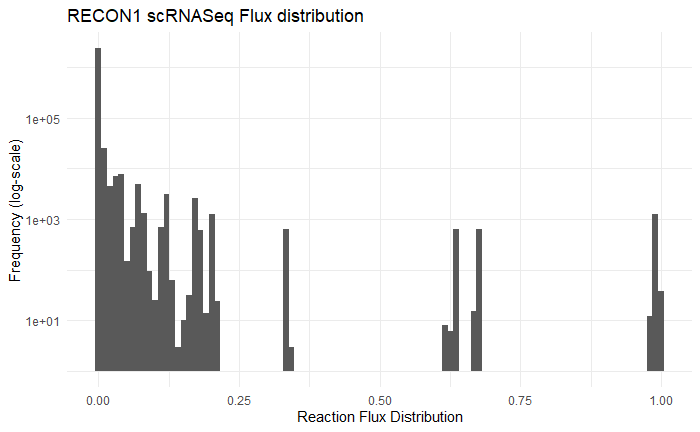

```r
library(reshape2)
tmp = melt(mnorm_flux)
ggplot(tmp, aes(x=value)) +
  geom_histogram(bins=100) +
  scale_y_continuous(trans='log10') +
  ggtitle("RECON1 scRNASeq Flux distribution") +
  xlab("Reaction Flux Distribution") +
  ylab("Frequency (log-scale)") +
  theme_minimal()
```

#### ii. Z-score Transformation

Alternatively, let’s see the impact of a Z-score transformation.

```r
tmp = abs(mnorm_flux)
zflux = (tmp - colMeans(tmp, na.rm=TRUE)) / apply(tmp, 2, sd, na.rm=TRUE)
```

Let’s visualize the Z-score distirbution.

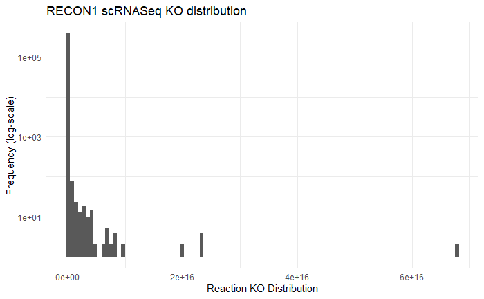

```r
library(reshape2)
tmp = melt(zflux)
ggplot(tmp, aes(x=value)) +
  geom_histogram(bins=100) +
  scale_y_continuous(trans='log10') +
  ggtitle("RECON1 scRNASeq KO distribution") +
  xlab("Reaction KO Distribution") +
  ylab("Frequency (log-scale)") +
  theme_minimal()
```

## Create density map profiles for glycolysis

In Mohit’s paper, they are able to show through density plots that there are deferentially active metabolic pathways. What this density plot will show are metabolic reactions for A549 glycolysis over time.

First, change the row to map to time.

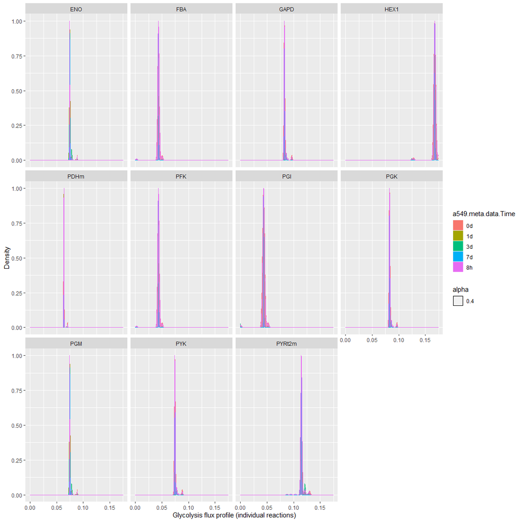

```r
time = data.frame(a549@meta.data$Time)
to_use = names(mnorm_flux) %in% c("GLCt1", "HEX1", "PGI", "PFK", "FBA", "GAPD", "PGK", "PGM", "ENO", "PYK", "PYRt2m", "PDHm")
glycolysis_ko = mnorm_flux[, to_use]
merged_meanko = cbind(time, glycolysis_ko)
tmp = melt(merged_meanko, id=c('a549.meta.data.Time'))
tmp2 = tmp[tmp$variable == "ENO", ]

library(dplyr)
library(tidyr)
library(ggplot2)

tmp %>%
  ggplot(aes(x=value, color=a549.meta.data.Time, fill=a549.meta.data.Time)) +
  geom_density(aes(y=..scaled.., alpha=0.4)) +
  facet_wrap(~variable, ncol=4) +
  labs(x="Glycolysis flux profile (individual reactions)", y="Density")
```

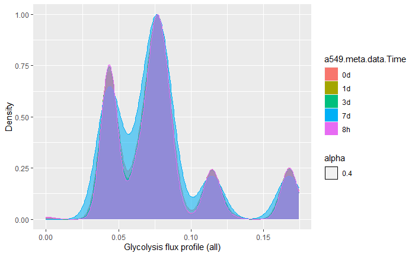

```r
ggplot(tmp, aes(x=value, color=a549.meta.data.Time, fill=a549.meta.data.Time)) +
geom_density(aes(y=..scaled.., alpha=0.4)) +
labs(x="Glycolysis flux profile (all)", y="Density")
```

### C. Merge with UMAP embedding

This combines the reaction ko data with the UMAP embedding.

```r
umap_data = data.frame(a549@reductions$umap@cell.embeddings)
```

#### i. Mean Normalization

```r
merged_meanflux = merge(umap_data, mnorm_flux, by.x='row.names', by.y='row.names')
rownames(merged_meanflux) = merged_meanflux$Row.names
merged_meanflux = merged_meanflux[, -1]
```

#### ii. Z-score

```r
merged_zflux = merge(umap_data, zflux, by.x='row.names', by.y='row.names')
rownames(merged_zflux) = merged_zflux$Row.names
merged_zflux = merged_zflux[, -1]
```

### D. Visualize KO Data

Let’s intialize some variables we need to declare for the visualization

#### i. Set 1: Flux

#### ii. Set 2: KO

```r
reactions_to_visualize = c("APAT2rm", "BALAtmr", "MMSAD3m",
                           "PCm", "GAPD", "EX_h_e")
reaction_names = c("3-Aminopropanoate:2-oxoglutarate aminotransferase (m)",
                   "Beta-alanine reversible mitochondrial transport (diffusion)",
                   "methylmalonate-semialdehyde dehydrogenase (malonic semialdehyde), mitochondrial",
                   "pyruvate carboxylase",
                   "glyceraldehyde-3-phosphate dehydrogenase",
                   "H+ exchange")
```

#### iii. Set 3: KO

```r
reactions_to_visualize = c("AKGMALtm", "ENO", "ACITL",
                           "CSNATr", "MDHm", "LDH_L")
reaction_names = c("AKG Transporter",
                   "Enolase",
                   "ATP Citrate Lyase",
                   "Carnitine o-acetyltransferase",
                   "Malate dehydrogenase")
```

#### iv. Set 4: KO

#### v. Visualize mean-norm KO

```r
tmp = merged_meanflux[, reactions_to_visualize]
tmp[is.na(tmp)] = 0
```

```r
tmp = merged_meanko[, reactions_to_visualize]
tmp[is.na(tmp)] = -1

tmp3 = rxnmap[rxnmap$rxn_ids %in% colnames(tmp2), ]
```

```r
p = list()
p[[1]] = ggplot(merged_meanflux, aes(x=UMAP_1, y=UMAP_2, color=tmp[, reactions_to_visualize[1]])) +
                geom_point(size=5) +
                theme_minimal() +
                labs(x="UMAP 1",
                     y="UMAP 2",
                     title=reaction_names[1],
                     color="Flux") +
                scale_colour_gradient2(low="black", mid = '#F29479', high='red', limits=c(0, max(tmp))) +
                theme(plot.title = element_text(size=26),
                            legend.text=element_text(size=22),
                            axis.title.x=element_text(size=22),
                            axis.title.y=element_text(size=22),
                            axis.text.x=element_text(size=22),
                            axis.text.y=element_text(size=22),
                            legend.position=c(0.05, 0.15),
                            legend.box="vertical",
                            legend.margin=margin(),
                            text=element_text(family="sans"))
```

```
Error in FUN(X[[i]], ...) :
  only defined on a data frame with all numeric variables
```

Create and visualize the final UMAP flux plot object.

[figure not shown]

```r
pC = scater::multiplot(pB, p[[1]], p[[2]],
                       p[[4]], p[[3]], p[[5]], cols=3)
```

```r
pC
```

| z | cells | name | grob |
| --- | --- | --- | --- |
| 1 | (1-1,1-1) | arrange | gtable[layout] |
| 2 | (2-2,1-1) | arrange | gtable[layout] |
| 3 | (1-1,2-2) | arrange | gtable[layout] |
| 4 | (2-2,2-2) | arrange | gtable[layout] |
| 5 | (1-1,3-3) | arrange | gtable[layout] |
| 6 | (2-2,3-3) | arrange | gtable[layout] |

#### v. Visualize Z-score KO

```r
tmp = merged_zflux[, reactions_to_visualize]
tmp[is.na(tmp)] = 0
```

```r
p = list()
p[[1]] = ggplot(merged_zflux, aes(x=UMAP_1, y=UMAP_2, color=tmp[, reactions_to_visualize[1]])) +
                geom_point(size=5) +
                theme_minimal() +
                labs(x="UMAP 1",
                     y="UMAP 2",
                     title=reaction_names[1],
                     color="Flux") +
                scale_colour_gradient2(low="black", mid = 'white', high='red') +
                theme(plot.title = element_text(size=26),
                            legend.text=element_text(size=22),
                            axis.title.x=element_text(size=22),
                            axis.title.y=element_text(size=22),
                            axis.text.x=element_text(size=22),
                            axis.text.y=element_text(size=22),
                            legend.position=c(0.05, 0.15),
                            legend.box="vertical",
                            legend.margin=margin(),
                            text=element_text(family="sans"))


p[[2]] = ggplot(merged_zflux, aes(x=UMAP_1, y=UMAP_2, color=tmp[, reactions_to_visualize[2]])) +
                geom_point(size=5) +
                theme_minimal() +
                labs(x="UMAP 1",
                     y="UMAP 2",
                     title=reaction_names[2],
                     color="Flux") +
                scale_colour_gradient2(low="black", mid = 'white', high='red') +
                theme(plot.title = element_text(size=26),
                            legend.text=element_text(size=22),
                            axis.title.x=element_text(size=22),
                            axis.title.y=element_text(size=22),
                            axis.text.x=element_text(size=22),
                            axis.text.y=element_text(size=22),
                            legend.position=c(0.05, 0.15),
                            legend.box="vertical",
                            legend.margin=margin(),
                            text=element_text(family="sans"))

p[[3]] = ggplot(merged_zflux, aes(x=UMAP_1, y=UMAP_2, color=tmp[, reactions_to_visualize[3]])) +
                geom_point(size=5) +
                theme_minimal() +
                labs(x="UMAP 1",
                     y="UMAP 2",
                     title=reaction_names[3],
                     color="Flux") +
                scale_colour_gradient2(low="black", mid = 'white', high='red') +
                theme(plot.title = element_text(size=26),
                            legend.text=element_text(size=22),
                            axis.title.x=element_text(size=22),
                            axis.title.y=element_text(size=22),
                            axis.text.x=element_text(size=22),
                            axis.text.y=element_text(size=22),
                            legend.position=c(0.05, 0.15),
                            legend.box="vertical",
                            legend.margin=margin(),
                            text=element_text(family="sans"))

p[[4]] = ggplot(merged_zflux, aes(x=UMAP_1, y=UMAP_2, color=tmp[, reactions_to_visualize[4]])) +
                geom_point(size=5) +
                theme_minimal() +
                labs(x="UMAP 1",
                     y="UMAP 2",
                     title=reaction_names[4],
                     color="Flux") +
                scale_colour_gradient2(low="black", mid = 'white', high='red') +
                theme(plot.title = element_text(size=26),
                            legend.text=element_text(size=22),
                            axis.title.x=element_text(size=22),
                            axis.title.y=element_text(size=22),
                            axis.text.x=element_text(size=22),
                            axis.text.y=element_text(size=22),
                            legend.position=c(0.05, 0.15),
                            legend.box="vertical",
                            legend.margin=margin(),
                            text=element_text(family="sans"))

p[[5]] = ggplot(merged_zflux, aes(x=UMAP_1, y=UMAP_2, color=tmp[, reactions_to_visualize[5]])) +
                geom_point(size=5) +
                theme_minimal() +
                labs(x="UMAP 1",
                     y="UMAP 2",
                     title=reaction_names[5],
                     color="Flux") +
                scale_colour_gradient2(low="black", mid = 'white', high='red') +
                theme(plot.title = element_text(size=26),
                            legend.text=element_text(size=22),
                            axis.title.x=element_text(size=22),
                            axis.title.y=element_text(size=22),
                            axis.text.x=element_text(size=22),
                            axis.text.y=element_text(size=22),
                            legend.position=c(0.05, 0.15),
                            legend.box="vertical",
                            legend.margin=margin(),
                            text=element_text(family="sans"))
```

Create and visualize the final UMAP flux plot object.

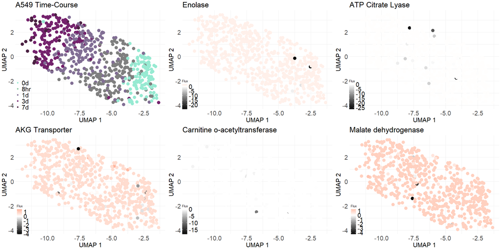

```r
pC = scater::multiplot(pB, p[[1]], p[[2]],
                       p[[4]], p[[3]], p[[5]], cols=3)
```

```r
pC
```

| z | cells | name | grob |
| --- | --- | --- | --- |
| 1 | (1-1,1-1) | arrange | gtable[layout] |
| 2 | (2-2,1-1) | arrange | gtable[layout] |
| 3 | (1-1,2-2) | arrange | gtable[layout] |
| 4 | (2-2,2-2) | arrange | gtable[layout] |
| 5 | (1-1,3-3) | arrange | gtable[layout] |
| 6 | (2-2,3-3) | arrange | gtable[layout] |